# Startup Success Prediction Dataset

[Dataset](https://www.kaggle.com/datasets/manishkc06/startup-success-prediction)

## Import necessary library

```python
import numpy as np # linear algebra
import pandas as pd # data processing
pd.set_option('display.max_columns', None)
import os
import matplotlib.pyplot as plt
import seaborn as sns
from sklearn.model_selection import train_test_split
from sklearn.ensemble import RandomForestClassifier
from sklearn.model_selection import GridSearchCV
from sklearn.metrics import classification_report
```

## Import dataset

```python
from google.colab import drive
drive.mount('/gdrive')
%cd /gdrive
```

```
Mounted at /gdrive
/gdrive
```

```python
data = pd.read_csv('/content/drive/MyDrive/Algoritma assignment/startup data.csv')
```

```python
data.info()
```

```
<class 'pandas.core.frame.DataFrame'>
RangeIndex: 923 entries, 0 to 922
Data columns (total 49 columns):
 #   Column                    Non-Null Count  Dtype
---  ------                    --------------  -----
 0   Unnamed: 0                923 non-null    int64
 1   state_code                923 non-null    object
 2   latitude                  923 non-null    float64
 3   longitude                 923 non-null    float64
 4   zip_code                  923 non-null    object
 5   id                        923 non-null    object
 6   city                      923 non-null    object
 7   Unnamed: 6                430 non-null    object
 8   name                      923 non-null    object
 9   labels                    923 non-null    int64
```

[output cut: 41 more lines]

```python
data = data.drop(['Unnamed: 0','Unnamed: 6','latitude','longitude','zip_code','id','name','object_id'], axis = 1)
```

## Data preprocessing

### State code variable

- **Check whether the state_code and state_code.1 variables contain the same data for each row** - One row is not equal to each other, because in state_code.1 variable it is a missing value. Therefore we assume the correct column is state_code (considering the city column).
- **Reduce the number of categories** - Top 5 categories of the state_code variable covers more than 80% from all the data. Therefore the other categories apart from the top 5 (CA,NY,MA,TX,WA) are considere as 'other'.

```python
print(data['state_code'].equals(data['state_code.1']))
```

```
False
```

```python
df = data.loc[data['state_code'] != data['state_code.1']]
df.style.set_properties(**{'background-color': 'yellow'}, subset=['state_code','state_code.1'])
```

|  | state_code | city | labels | founded_at | closed_at | first_funding_at | last_funding_at | age_first_funding_year | age_last_funding_year | age_first_milestone_year | age_last_milestone_year | relationships | funding_rounds | funding_total_usd | milestones | state_code.1 | is_CA | is_NY | is_MA | is_TX | is_otherstate | category_code | is_software | is_web | is_mobile | is_enterprise | is_advertising | is_gamesvideo | is_ecommerce | … |
| --- | --- | --- | --- | --- | --- | --- | --- | --- | --- | --- | --- | --- | --- | --- | --- | --- | --- | --- | --- | --- | --- | --- | --- | --- | --- | --- | --- | --- | --- | --- |
| 515 | CA | Menlo Park | 0 | 1/1/2005 | 9/1/2010 | 3/1/2007 | 4/15/2008 | 2.161600 | 3.287700 | 3.498600 | 7.690400 | 13 | 2 | 33000000 | 4 | nan | 0 | 0 | 0 | 0 | 0 | search | 0 | 0 | 0 | 0 | 0 | 0 | 0 | … |

```python
state = data['state_code'].value_counts().to_frame()
state['proportion'] = state['state_code']/sum(state['state_code'])*100
state.head()
```

|  | state_code | proportion |
| --- | --- | --- |
| CA | 488 | 52.871073 |
| NY | 106 | 11.484290 |
| MA | 83 | 8.992416 |
| TX | 42 | 4.550379 |
| WA | 42 | 4.550379 |

```python
data['State'] = 'other'
data.loc[(data['state_code'] == 'CA'), 'State'] = 'CA'
data.loc[(data['state_code'] == 'NY'), 'State'] = 'NY'
data.loc[(data['state_code'] == 'MA'), 'State'] = 'MA'
data.loc[(data['state_code'] == 'TX'), 'State'] = 'TX'
data.loc[(data['state_code'] == 'WA'), 'State'] = 'WA'
```

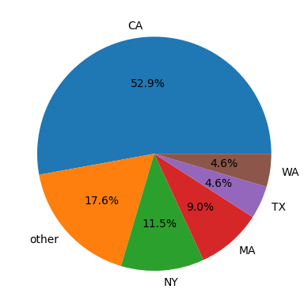

```python
state_count = data['State'].value_counts()
plt.pie(state_count, labels = state_count.index, autopct = '%1.1f%%')
plt.show()
```

```python
data = data.drop(['state_code','state_code.1','is_CA', 'is_NY', 'is_MA', 'is_TX', 'is_otherstate'],axis =1)
```

### Category code variable

```python
category = data['category_code'].value_counts().to_frame()
category['proportion'] = category['category_code']/sum(category['category_code'])*100
category.head()
```

|  | category_code | proportion |
| --- | --- | --- |
| software | 153 | 16.576381 |
| web | 144 | 15.601300 |
| mobile | 79 | 8.559047 |
| enterprise | 73 | 7.908992 |
| advertising | 62 | 6.717226 |

```python
data['category'] = 'other'
data.loc[(data['category_code'] == 'software'), 'category'] = 'software'
data.loc[(data['category_code'] == 'web'), 'category'] = 'web'
data.loc[(data['category_code'] == 'mobile'), 'category'] = 'mobile'
data.loc[(data['category_code'] == 'enterprise'), 'category'] = 'enterprise'
data.loc[(data['category_code'] == 'advertising'), 'category'] = 'advertising'
data.loc[(data['category_code'] == 'games_video'), 'category'] = 'games_video'
data.loc[(data['category_code'] == 'semiconductor'), 'category'] = 'semiconductor'
data.loc[(data['category_code'] == 'network_hosting'), 'category'] = 'network_hosting'
data.loc[(data['category_code'] == 'biotech'), 'category'] = 'biotech'
data.loc[(data['category_code'] == 'hardware'), 'category'] = 'hardware'
```

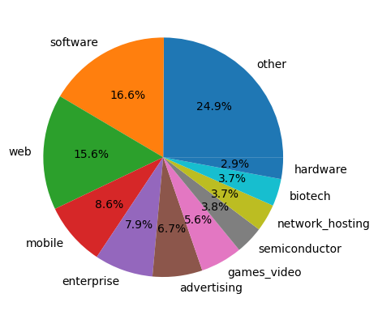

```python
category_count = data['category'].value_counts()
plt.pie(category_count, labels = category_count.index, autopct = '%1.1f%%')
plt.show()
```

```python
data = data.drop(['category_code','is_software','is_web','is_mobile','is_enterprise','is_advertising','is_gamesvideo','is_ecommerce','is_biotech','is_consulting','is_othercategory'],axis = 1)
```

### Labels and status variable

Check whether the labels and status variables contain the same data for each row

```python
data['status'] = np.where(data['status']=='acquired',1,0)
```

```python
print(data['labels'].equals(data['status']))
```

```
False
```

```python
prop_df = data.groupby('status').size().reset_index(name = 'counts')
prop_df['proportions'] = prop_df['counts']/prop_df['counts'].sum()
```

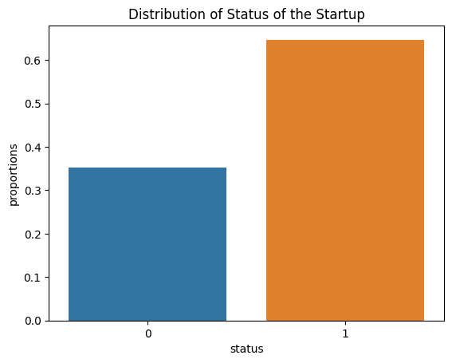

```python
sns.barplot(data = prop_df, x = 'status', y = 'proportions')
plt.title('Distribution of Status of the Startup')
```

### Founded_at and Closed_at variable

- Changed the **Founded_at** column into a new column **Founded_year**
- Check the **missing values in closed_at** variable

```python
data['founded_at'] = data['founded_at'].apply(pd.to_datetime)
data['founded_year'] = data['founded_at'].dt.strftime('%Y')
```

```python
data['closed_at'] = data['closed_at'].fillna(0)
data['closed_at'] = data['closed_at'].apply(str)
```

```python
closed = []
for index, row in data.iterrows():
    if ((row['closed_at'] != '0') and (row['status'] == 1)) == True:
        closed.append(True)
```

```python
closed.count(True)
```

```
9
```

```python
df = data.loc[(data['closed_at']!='0') & (data['status'] == 1)]
df.style.set_properties(**{'background-color': 'yellow'}, subset=['closed_at','status'])
```

|  | city | labels | founded_at | closed_at | first_funding_at | last_funding_at | age_first_funding_year | age_last_funding_year | age_first_milestone_year | age_last_milestone_year | relationships | funding_rounds | funding_total_usd | milestones | has_VC | has_angel | has_roundA | has_roundB | has_roundC | has_roundD | avg_participants | is_top500 | status | State | category | founded_year |
| --- | --- | --- | --- | --- | --- | --- | --- | --- | --- | --- | --- | --- | --- | --- | --- | --- | --- | --- | --- | --- | --- | --- | --- | --- | --- | --- |
| 73 | San Francisco | 1 | 2003-01-01 00:00:00 | 2/1/2001 | 9/1/2004 | 5/1/2012 | 1.668500 | 9.337000 | 7.380800 | 10.474000 | 17 | 4 | 40400000 | 3 | 0 | 0 | 1 | 1 | 1 | 1 | 1.666700 | 1 | 1 | CA | advertising | 2003 |
| 104 | San Francisco | 1 | 2007-07-01 00:00:00 | 9/1/2011 | 1/1/2007 | 10/1/2008 | -0.495900 | 1.254800 | 2.172600 | 4.600000 | 21 | 2 | 6000000 | 2 | 0 | 1 | 1 | 0 | 0 | 0 | 4.000000 | 1 | 1 | CA | web | 2007 |
| 291 | Columbia | 1 | 2000-01-01 00:00:00 | 10/15/2009 | 4/24/2007 | 4/24/2007 | 7.315100 | 7.315100 | 5.005500 | 5.005500 | 6 | 1 | 16980999 | 1 | 0 | 0 | 0 | 1 | 0 | 0 | 1.000000 | 1 | 1 | other | biotech | 2000 |
| 342 | Austin | 1 | 2003-01-01 00:00:00 | 6/1/2013 | 6/14/2007 | 3/23/2010 | 4.452100 | 7.227400 | 7.005500 | 7.005500 | 5 | 2 | 5992316 | 1 | 1 | 0 | 1 | 0 | 0 | 0 | 2.000000 | 0 | 1 | TX | enterprise | 2003 |
| 381 | Redwood City | 1 | 2006-03-01 00:00:00 | 1/1/2012 | 6/1/2007 | 1/14/2008 | 1.252100 | 1.874000 | 4.717800 | 5.095900 | 13 | 3 | 2600000 | 2 | 0 | 1 | 1 | 0 | 0 | 0 | 3.666700 | 1 | 1 | CA | network_hosting | 2006 |
| 445 | Cambridge | 1 | 2006-01-01 00:00:00 | 1/1/2008 | 1/3/2008 | 1/3/2008 | 2.005500 | 2.005500 | 0.000000 | 0.000000 | 1 | 1 | 30000000 | 1 | 1 | 0 | 0 | 0 | 0 | 0 | 2.000000 | 1 | 1 | MA | other | 2006 |
| 473 | Burlingame | 1 | 2007-01-01 00:00:00 | 12/1/2011 | 8/1/2007 | 7/6/2009 | 0.580800 | 2.512300 | 0.591800 | 4.969900 | 9 | 3 | 1415000 | 4 | 1 | 1 | 0 | 0 | 0 | 0 | 1.000000 | 1 | 1 | CA | other | 2007 |
| 560 | San Francisco | 1 | 2006-10-01 00:00:00 | 11/16/2010 | 12/1/2007 | 12/1/2007 | 1.167100 | 1.167100 | 1.926000 | 4.013700 | 19 | 1 | 3000000 | 4 | 0 | 0 | 1 | 0 | 0 | 0 | 2.000000 | 1 | 1 | CA | advertising | 2006 |
| 756 | Mountain View | 1 | 2004-12-06 00:00:00 | 5/19/2011 | 4/4/2006 | 8/22/2007 | 1.326000 | 2.709600 | 4.369900 | 6.463000 | 6 | 2 | 29000000 | 3 | 0 | 0 | 0 | 1 | 1 | 0 | 2.500000 | 1 | 1 | CA | software | 2004 |

```python
data = data.drop(df.index.tolist()).reset_index().drop(['index'],axis = 1)
```

```python
data = data.drop(['founded_at','closed_at'], axis = 1)
```

```python
prop_df = data.groupby('founded_year').size().reset_index(name = 'counts')
prop_df['proportions'] = prop_df['counts']/prop_df['counts'].sum()
```

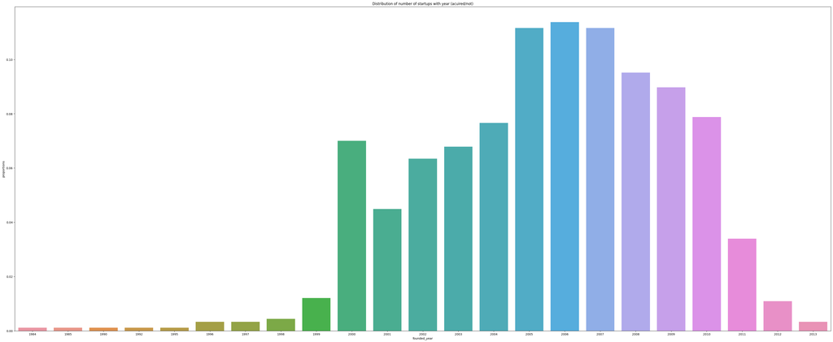

```python
fig, ax = plt.subplots(figsize = (50,20))
sns.barplot(data = prop_df, x = 'founded_year', y = 'proportions')
plt.title('Distribution of number of startups with year (acuired/not)')
```

### **First_funding_at** and **last_funding_at** variables

```python
data = data.drop(['first_funding_at','last_funding_at'],axis=1)
```

Changing the data types

```python
data['has_VC'] = data['has_VC'].apply(str)
data['has_angel'] = data['has_angel'].apply(str)
data['has_roundA'] = data['has_roundA'].apply(str)
data['has_roundB'] = data['has_roundB'].apply(str)
data['has_roundC'] = data['has_roundC'].apply(str)
data['has_roundD'] = data['has_roundD'].apply(str)
data['is_top500'] = data['is_top500'].apply(str)
data['status'] = data['status'].apply(str)
```

Handling invalid values in age first and last funding year, age first and last milestone year

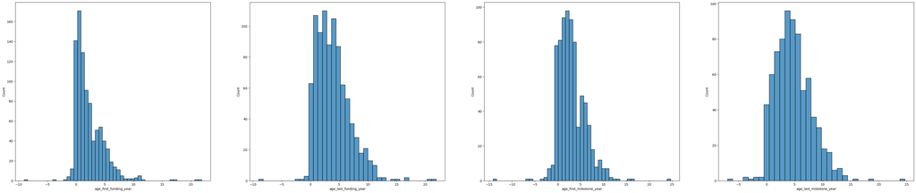

```python
var = ['age_first_funding_year','age_last_funding_year','age_first_milestone_year','age_last_milestone_year']

fig, axes = plt.subplots(nrows = 1, ncols = 4, figsize = (50,10))

for k, ax in zip(range(4), axes.flatten()):
    sns.histplot(data = data, x = f'{var[k]}', ax = ax)
```

```python
data['age_first_funding_year'] = np.where(data['age_first_funding_year']<0,0,data['age_first_funding_year'])
data['age_last_funding_year'] = np.where(data['age_last_funding_year']<0,0,data['age_last_funding_year'])
data['age_first_milestone_year'] = np.where(data['age_first_milestone_year']<0,0,data['age_first_milestone_year'])
data['age_last_milestone_year'] = np.where(data['age_last_milestone_year']<0,0,data['age_last_milestone_year'])
```

Handling missing values (1)

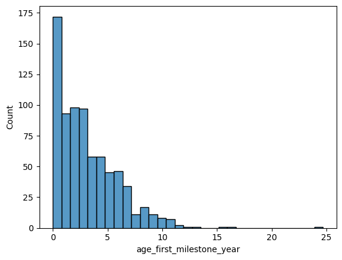

```python
sns.histplot(data = data, x = 'age_first_milestone_year')
```

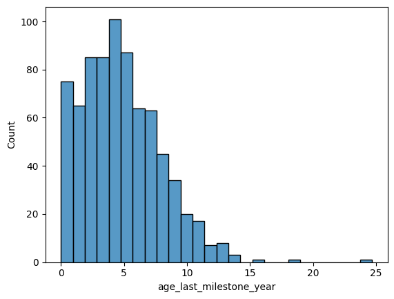

```python
sns.histplot(data = data, x = 'age_last_milestone_year')
```

```python
data['age_first_milestone_year'] = data['age_first_milestone_year'].fillna(data['age_first_milestone_year'].mode()[0])
data['age_last_milestone_year'] = data['age_last_milestone_year'].fillna(data['age_last_milestone_year'].mode()[0])
```

## Visualization

```python
data.info()
```

```
<class 'pandas.core.frame.DataFrame'>
RangeIndex: 914 entries, 0 to 913
Data columns (total 22 columns):
 #   Column                    Non-Null Count  Dtype
---  ------                    --------------  -----
 0   city                      914 non-null    object
 1   labels                    914 non-null    int64
 2   age_first_funding_year    914 non-null    float64
 3   age_last_funding_year     914 non-null    float64
 4   age_first_milestone_year  914 non-null    float64
 5   age_last_milestone_year   914 non-null    float64
 6   relationships             914 non-null    int64
 7   funding_rounds            914 non-null    int64
 8   funding_total_usd         914 non-null    int64
 9   milestones                914 non-null    int64
 10  has_VC                    914 non-null    object
 11  has_angel                 914 non-null    object
 12  has_roundA                914 non-null    object
 13  has_roundB                914 non-null    object
 14  has_roundC                914 non-null    object
 15  has_roundD                914 non-null    object
 16  avg_participants          914 non-null    float64
 17  is_top500                 914 non-null    object
 18  status                    914 non-null    object
 19  State                     914 non-null    object
 20  category                  914 non-null    object
 21  founded_year              914 non-null    object
dtypes: float64(5), int64(5), object(12)
memory usage: 157.2+ KB
```

### Summary of cattegorical variables

```python
data.describe(include = ['object'])
```

|  | city | has_VC | has_angel | has_roundA | has_roundB | has_roundC | has_roundD | is_top500 | status | State | category | founded_year |
| --- | --- | --- | --- | --- | --- | --- | --- | --- | --- | --- | --- | --- |
| count | 914 | 914 | 914 | 914 | 914 | 914 | 914 | 914 | 914 | 914 | 914 | 914 |
| unique | 220 | 2 | 2 | 2 | 2 | 2 | 2 | 2 | 2 | 6 | 11 | 23 |
| top | San Francisco | 0 | 0 | 1 | 0 | 0 | 0 | 1 | 1 | CA | other | 2006 |
| freq | 125 | 616 | 682 | 464 | 555 | 701 | 823 | 739 | 588 | 482 | 228 | 104 |

### State vs status

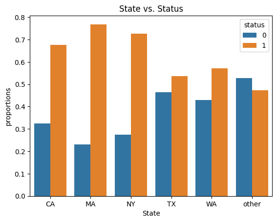

```python
prop_df = data.groupby(['State','status'],group_keys = True).size().reset_index(name='count')
prop_df['proportions'] = prop_df.groupby('State')['count'].apply(lambda x: x/x.sum())
sns.barplot(data = prop_df, x = 'State', y = 'proportions',hue = 'status')
plt.title('State vs. Status')
```

### State vs category

```python
cat_state = pd.crosstab(index = data['State'], columns = data['category'])
```

```python
cat_state
```

| category State | advertising | biotech | enterprise | games_video | hardware | mobile | network_hosting | other | semiconductor | software | web |
| --- | --- | --- | --- | --- | --- | --- | --- | --- | --- | --- | --- |
| CA | 31 | 20 | 35 | 32 | 21 | 39 | 15 | 114 | 23 | 73 | 79 |
| MA | 6 | 5 | 5 | 0 | 2 | 10 | 3 | 15 | 2 | 24 | 10 |
| NY | 12 | 1 | 5 | 14 | 1 | 9 | 1 | 35 | 0 | 7 | 21 |
| TX | 0 | 0 | 5 | 1 | 1 | 2 | 2 | 13 | 4 | 8 | 5 |
| WA | 1 | 0 | 5 | 2 | 1 | 5 | 5 | 9 | 0 | 7 | 7 |
| other | 10 | 7 | 17 | 3 | 1 | 14 | 7 | 42 | 6 | 33 | 21 |

### Category vs status

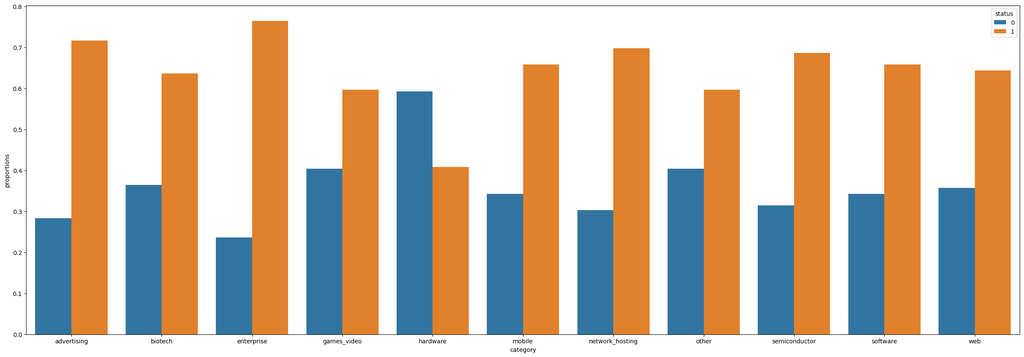

```python
fig, ax = plt.subplots(figsize = (30,10))
prop_df = data.groupby(['category','status']).size().reset_index(name='counts')
prop_df['proportions'] = prop_df.groupby('category')['counts'].apply(lambda x: x/float(x.sum()))
sns.barplot(data = prop_df, x = 'category', y = 'proportions',hue = 'status')
```

### Category vs founded year

```python
cat_year = pd.crosstab(index = data['founded_year'], columns = data['category'])
```

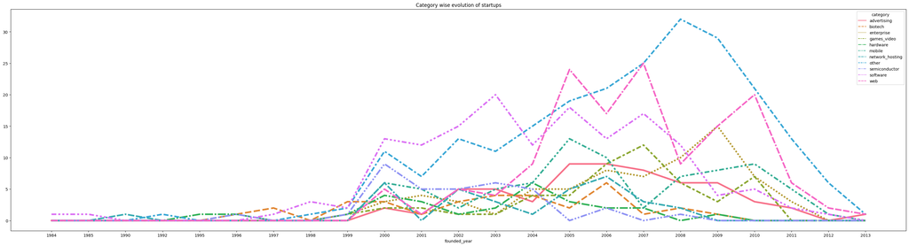

```python
fig, ax = plt.subplots(figsize=(40,10))
sns.lineplot(data = cat_year, lw = 4)
plt.title('Category wise evolution of startups')
```

### Founded year vs total funding

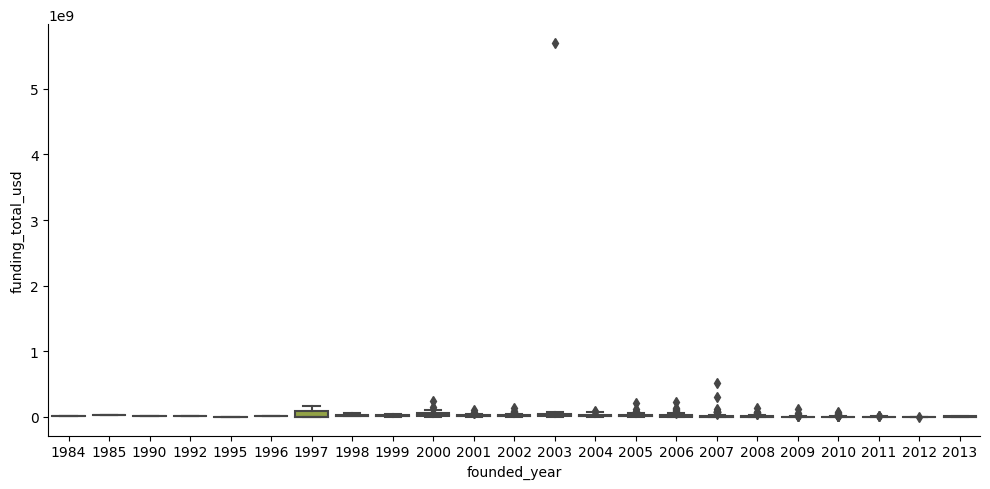

```python
sns.catplot(data=data, x="founded_year", y="funding_total_usd", kind="box",height=5, aspect=2,order = ['1984','1985','1990','1992','1995','1996','1997','1998','1999','2000','2001','2002','2003','2004','2005','2006','2007','2008','2009','2010','2011','2012','2013'])
```

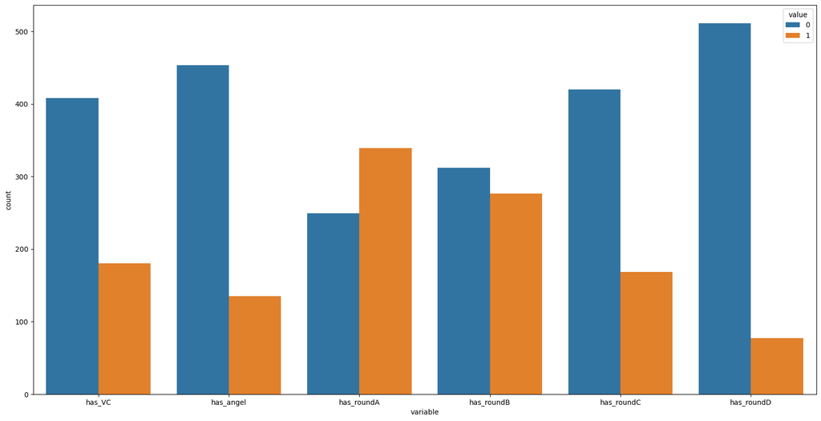

```python
fig, ax = plt.subplots(figsize = (20,10))
d = data.loc[data['status'] == '1']
f = d[["has_VC","has_angel","has_roundA","has_roundB","has_roundC","has_roundD"]]
sns.countplot(data = pd.melt(f), x = 'variable', hue = 'value')
```

### Quantitative variables summary

```python
data.describe(include = ['float64','int64'])
```

[output not shown]

### Correlation plot

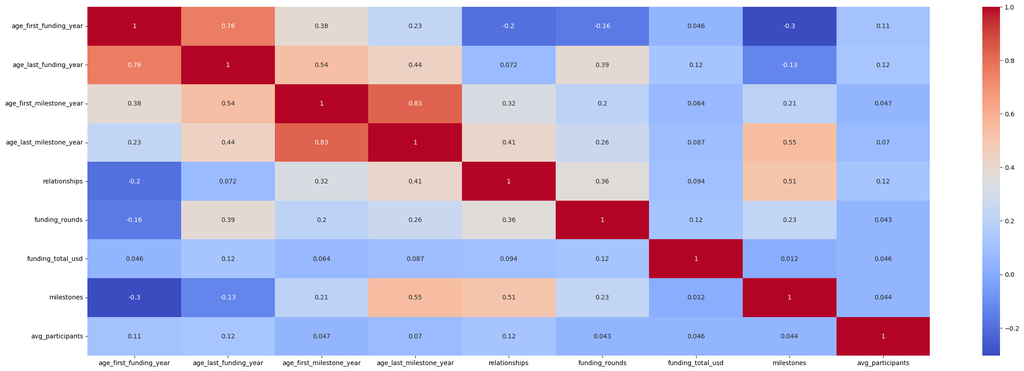

```python
fig, ax = plt.subplots(figsize = (30,10))
corr = data.select_dtypes(include=['int64','float64']).corr()
sns.heatmap(corr, cmap = 'coolwarm', annot = True)
```